# FAO_Markdown

### Importation et préparation des données

```r
#load libraries
library("stringr")
library("tidyverse")
#read the folder of csv files

fichiers<-list.files(path = "./fichiers_csv", pattern = NULL, all.files = FALSE,
                     full.names = FALSE, recursive = FALSE,
                     ignore.case = FALSE, include.dirs = FALSE, no.. = FALSE)

#put csv files in tables
for (i in 1:length(fichiers)){
  assign(x=str_sub(fichiers[i],1,-5),
         value=read.csv(paste0("./fichiers_csv/",fichiers[i])))
}
```

```r
#concat tables bilan_prod_animaux and bilan_vegetaux adding "origin" variable

bilan_prod_animaux$origin<-"animal"
temp<-bilan_prod_animaux

for (i in c('4','5','6','7')){
  df<-get(paste0("bilan_vegetaux_201",i))
  df$origin="vegetal"
  temp<-bind_rows(temp,df)
}

temp<-temp%>%select(-c(1,2,5,9,13,14))
```

```r
# Check units to transpose
l<-unique(temp$Element)

for (i in c(1:13)){
  v<-temp%>%filter(Element==l[i],Unit!="1000 tonnes")
  print(dim(v)[1])
}
```

```
## [1] 0
## [1] 0
## [1] 0
## [1] 0
## [1] 0
## [1] 0
## [1] 0
## [1] 0
## [1] 0
## [1] 0
## [1] 0
## [1] 0
## [1] 0
```

```r
#transpose to have products dataset
temp<-temp%>%select(-Unit)

prod_t<-temp%>%pivot_wider(names_from = Element, values_from = Value)


prod_t<-prod_t%>%rename("country_code"=Area.Code,
                        "country"=Area,
                        "item_code"=Item.Code,
                        "item"=Item,
                        "year"=Year,
                        "production_1000t"=Production,
                        "import_qu_1000t"=`Import Quantity`,
                        "stock_var_1000t"=`Stock Variation`,
                        "export_qu_1000t"=`Export Quantity`,
                        "domestic_supply_qu_1000t"=`Domestic supply quantity`,
                        "feed_1000t"=Feed,
                        "seed_1000t"=Seed,
                        "losses_1000t"=Losses,
                        "processing_1000t"=Processing,
                        "other_uses_1000t"=`Other uses (non-food)`,
                        "tourist_consumption_1000t"=`Tourist consumption`,
                        "residuals_1000t"=Residuals,
                        "food_1000t"=Food,
                        "food_sup_qu_kg/cpt/yr"=`Food supply quantity (kg/capita/yr)`,
                        "food_sup_qu_kcal/cpt/day" = `Food supply (kcal/capita/day)`,
                        "protein_sup_qu_g/cpt/day"=`Protein supply quantity (g/capita/day)`,
                        "fat_sup_qu_g/cpt/day"=`Fat supply quantity (g/capita/day)`)
```

```r
#drop duplicate country (China)
prod_t<-prod_t%>%filter(country_code!=351)

colnames(prod_t)
```

```
##  [1] "country_code"              "country"
##  [3] "item_code"                 "item"
##  [5] "year"                      "origin"
##  [7] "production_1000t"          "import_qu_1000t"
##  [9] "stock_var_1000t"           "export_qu_1000t"
## [11] "domestic_supply_qu_1000t"  "feed_1000t"
## [13] "seed_1000t"                "losses_1000t"
## [15] "processing_1000t"          "other_uses_1000t"
## [17] "tourist_consumption_1000t" "residuals_1000t"
## [19] "food_1000t"                "food_sup_qu_kg/cpt/yr"
## [21] "food_sup_qu_kcal/cpt/day"  "protein_sup_qu_g/cpt/day"
## [23] "fat_sup_qu_g/cpt/day"
```

### Population table and analysis

```r
population_table<- population_data%>%
  rename('country'=Area,'country_code'=Area.Code,'year'=Year)%>%
  mutate(population=Value*1000)%>%
  filter(country_code!=351)%>%
  select(country,country_code,year,population)
```

```r
colnames(population_table)
```

```
## [1] "country"      "country_code" "year"         "population"
```

### 1.1 taille de la population mondiale depuis 2014

```r
pop_totale<-population_table%>%group_by(year)%>%summarise(total=sum(population,na.rm=TRUE))
pop_totale
```

```
## # A tibble: 4 x 2
##    year      total
##   <int>      <dbl>
## 1  2014 7089471330
## 2  2015 7170159000
## 3  2016 7250317980
## 4  2017 7329868960
```

### 2. dispo_alim table and analysis

```r
dispo_alim_table<-prod_t%>% mutate(food_sup_t=food_1000t*1000) %>%
  select(country,country_code,year,item,item_code, origin,`food_sup_qu_kcal/cpt/day`,
         food_sup_t,`protein_sup_qu_g/cpt/day`,`fat_sup_qu_g/cpt/day`)
```

```r
colnames(dispo_alim_table)
```

```
##  [1] "country"                  "country_code"
##  [3] "year"                     "item"
##  [5] "item_code"                "origin"
##  [7] "food_sup_qu_kcal/cpt/day" "food_sup_t"
##  [9] "protein_sup_qu_g/cpt/day" "fat_sup_qu_g/cpt/day"
```

```r
cereal<-dispo_alim_table%>%
  select(item,item_code) %>%
  filter(grepl("(cereals|wheat|rye|rice|barley|oats|corn|maize|millet|sorghum)",item,ignore.case = TRUE),
         grepl("oil",item,ignore.case = TRUE)==FALSE)%>%distinct()

prod_t<-prod_t%>%mutate(is_cereal=ifelse(item %in% cereal$item,TRUE,FALSE))
```

```r
colnames(prod_t)
```

```
##  [1] "country_code"              "country"
##  [3] "item_code"                 "item"
##  [5] "year"                      "origin"
##  [7] "production_1000t"          "import_qu_1000t"
##  [9] "stock_var_1000t"           "export_qu_1000t"
## [11] "domestic_supply_qu_1000t"  "feed_1000t"
## [13] "seed_1000t"                "losses_1000t"
## [15] "processing_1000t"          "other_uses_1000t"
## [17] "tourist_consumption_1000t" "residuals_1000t"
## [19] "food_1000t"                "food_sup_qu_kg/cpt/yr"
## [21] "food_sup_qu_kcal/cpt/day"  "protein_sup_qu_g/cpt/day"
## [23] "fat_sup_qu_g/cpt/day"      "is_cereal"
```

####2.1 liste des céréales selon la FAO

```r
cereal$item
```

```
## [1] "Wheat and products"   "Rice and products"    "Barley and products"
## [4] "Maize and products"   "Rye and products"     "Oats"
## [7] "Millet and products"  "Sorghum and products" "Cereals, Other"
```

#### 2.1.2 calcul de la proportion de nourriture céréalières destinée aux animaux depuis 2014

```r
prod_t%>%filter(item %in% cereal$item)%>%group_by(year)%>%
  summarise(prop_prct=100*sum(feed_1000t,na.rm=TRUE)/(sum(food_1000t,na.rm=TRUE)+sum(feed_1000t,na.rm=TRUE)))
```

```
## # A tibble: 4 x 2
##    year prop_prct
##   <int>     <dbl>
## 1  2014      43.0
## 2  2015      42.9
## 3  2016      43.5
## 4  2017      43.8
```

### 2.2 Comment mesure-t-on la dispo alimentaire?

#### 2.2.1 dispo alim par pays et par produit

```r
jointure<-left_join(prod_t,population_table,by=c("country_code","country","year"))
```

#### 2.2.2 et 2.2.3 ratio énergie/poids et ratio énergie/proteine

```r
jointure<-jointure%>%
  mutate(ratio_kcal_kg=ifelse(food_1000t!=0,round(`food_sup_qu_kcal/cpt/day`*365*population/(food_1000t*1000*1000),2),NA))
```

```r
jointure<-jointure%>%mutate(ratio_protein_prct=ifelse(`food_sup_qu_kg/cpt/yr`!=0,
                                                 100*`protein_sup_qu_g/cpt/day`*365/(1000*`food_sup_qu_kg/cpt/yr`),
                                                 NA)) %>%
                    filter(ratio_kcal_kg>20,ratio_kcal_kg<=9200)

ratios<-jointure%>%select(country_code,country,item_code,item,origin,ratio_kcal_kg,ratio_protein_prct)
```

```r
colnames(ratios)
```

```
## [1] "country_code"       "country"            "item_code"
## [4] "item"               "origin"             "ratio_kcal_kg"
## [7] "ratio_protein_prct"
```

### 2.3 Top 20 des aliments

#### 2.3.1 Aliments les + caloriques : Citez 5 aliments parmi les 20 aliments les plus caloriques, en utilisant le ratio énergie/poids ?

```r
foodmoy<- ratios%>%
  group_by(item)%>%
  summarise(moykcal_kg=mean(ratio_kcal_kg,na.rm=TRUE),moyprot=mean(ratio_protein_prct,na.rm=TRUE))%>%
  arrange(desc(moykcal_kg))%>%
  head(20)
foodmoy$moyprot<-formatC(foodmoy$moyprot,format="g", digits=5)

print(foodmoy)
```

```
## # A tibble: 20 x 3
##    item                     moykcal_kg moyprot
##    <chr>                         <dbl> <chr>
##  1 Ricebran Oil                  8682. "     0"
##  2 Palm Oil                      8665. "     0"
##  3 Fish, Body Oil                8564. "     0"
##  4 Sunflowerseed Oil             8548. "     0"
##  5 Soyabean Oil                  8526. "     0"
##  6 Rape and Mustard Oil          8359. "0.00033503"
##  7 Sesameseed Oil                8355. "     0"
##  8 Cottonseed Oil                8277. "     0"
##  9 Groundnut Oil                 8235. "     0"
## 10 Olive Oil                     8220. "     0"
## 11 Palmkernel Oil                8188. "     0"
## 12 Maize Germ Oil                8086. "     0"
## 13 Coconut Oil                   7800. "     0"
## 14 Fats, Animals, Raw            7608. " 1.697"
## 15 Oilcrops Oil, Other           7269. "0.44819"
## 16 Butter, Ghee                  7171. "0.73616"
## 17 Cocoa Beans and products      6086. "10.458"
## 18 Sesame seed                   5699. "17.813"
## 19 Fish, Liver Oil               5248. "     0"
## 20 Oilcrops, Other               4748. "18.465"
```

#### Citez 5 aliments parmi les 20 aliments les plus riches en protéines

```r
foodmoyprot<-ratios%>%
  group_by(item)%>%
  summarise(moykcal_kg=mean(ratio_kcal_kg,na.rm=TRUE),moyprot=mean(ratio_protein_prct,na.rm=TRUE))%>%
  arrange(desc(moyprot))%>%
  head(20)
print(foodmoyprot)
```

```
## # A tibble: 20 x 3
##    item                       moykcal_kg moyprot
##    <chr>                           <dbl>   <dbl>
##  1 Soyabeans                       3181.    31.7
##  2 Peas                            3524.    22.6
##  3 Pulses, Other and products      3383.    22.1
##  4 Beans                           3386.    21.9
##  5 Meat, Other                     1388.    20.4
##  6 Groundnuts (Shelled Eq)         4437.    19.7
##  7 Oilcrops, Other                 4748.    18.5
##  8 Sesame seed                     5699.    17.8
##  9 Offals, Edible                  1147.    17.6
## 10 Rape and Mustardseed            4518.    15.6
## 11 Infant food                     3707.    15.2
## 12 Bovine Meat                     1744.    15.0
## 13 Cephalopods                      822.    14.4
## 14 Mutton & Goat Meat              2034.    13.8
## 15 Poultry Meat                    1311.    12.8
## 16 Pimento                         3318.    12.2
## 17 Pelagic Fish                     938.    12.2
## 18 Marine Fish, Other               815.    11.6
## 19 Sunflower seed                  3010.    11.6
## 20 Spices, Other                   3473.    11.2
```

### 2.4 Disponibilité mondiale

#### 2.4.1 en végétaux uniquement : Calculer, pour les produits végétaux uniquement, la disponibilité intérieure mondiale exprimée en kcal et en Kg protéines pour chaque année et tracer la viz correspondante ?

```r
dispo_veg_kcal<-jointure%>%filter(origin=="vegetal")%>%
                  mutate(dom_sup_kcal_country=domestic_supply_qu_1000t*1000000*ratio_kcal_kg)%>%
                  group_by(year)%>%
                  summarise(dom_sup_kcal=sum(dom_sup_kcal_country,na.rm=TRUE))
dispo_veg_prot<-jointure%>%filter(origin=="vegetal")%>%
                 mutate(dom_sup_kg_prot_country=domestic_supply_qu_1000t*1000000*ratio_protein_prct*0.01)%>%
                 group_by(year)%>%
                 summarise(dom_sup_kg_prot=sum(dom_sup_kg_prot_country,na.rm=TRUE))
```

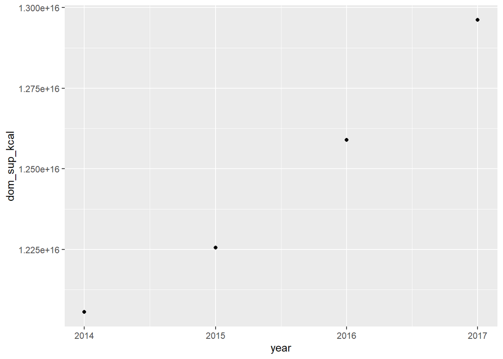

```r
ggplot(dispo_veg_kcal)+geom_point(aes(x=year,y=dom_sup_kcal))
```

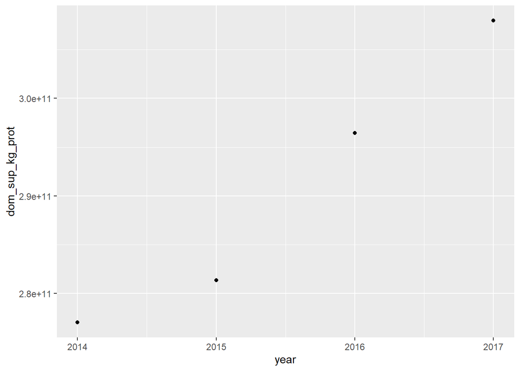

```r
ggplot(dispo_veg_prot)+ geom_point(aes(x=year,y=dom_sup_kg_prot))
```